# US Top Income Share 2013

coop711

2015년 5월 3일

## Data Preparation

준비한 자료는 E. Saez 교수의 홈페이지에 있는 TabFig2013prel.xls 인데 이를 약간의 작업을 거쳐 R에서 불러들이기 편하게 고쳐놓았다.

```r
load("US_top_income_share_2013.rda")
ls()
```

```
## [1] "add12_13"                "P99_99.9"
## [3] "P99.5_99.99"             "top.income.shares"
## [5] "top.income.shares.2"     "US.top.income.shares"
## [7] "US.top.income.shares.13" "v"
## [9] "year"
```

작업을 마친 자료파일은 `US.top.income.shares.13`이며, 이 자료의 구조와 앞의 몇 열의 값은 다음과 같다.

```r
str(US.top.income.shares.13)
```

```
## 'data.frame':    101 obs. of  14 variables:
##  $ year       : int  1913 1914 1915 1916 1917 1918 1919 1920 1921 1922 ...
##  $ P90_100    : num  NA NA NA NA 40.5 ...
##  $ P95_100    : num  NA NA NA NA 30.6 ...
##  $ P99_100    : num  18 18.2 17.6 19.3 17.7 ...
##  $ P99.5_100  : num  14.7 15.1 14.6 16.4 14.3 ...
##  $ P99.9_100  : num  8.62 8.6 9.22 10.51 8.4 ...
##  $ P99.99_100 : num  2.76 2.73 4.36 4.78 3.37 2.45 2.29 1.66 1.69 2.27 ...
##  $ P90_95     : num  NA NA NA NA 9.87 ...
##  $ P95_99     : num  NA NA NA NA 12.9 ...
##  $ P99_99.5   : num  3.23 3.08 3 2.94 3.39 3.53 3.77 3.69 3.94 4 ...
##  $ P99.5_99.9 : num  6.11 6.48 5.36 5.86 5.94 5.71 6.01 5.79 6.1 6.42 ...
##  $ P99.9_99.99: num  5.86 5.87 4.86 5.73 5.04 4.26 4.34 3.69 3.91 4.36 ...
##  $ P99.5_99.99: num  12 12.3 10.2 11.6 11 ...
##  $ P99_99.9   : num  9.34 9.56 8.36 8.8 9.34 ...
```

```r
US.top.income.shares.13[, 1:8]
```

```
##     year P90_100 P95_100 P99_100 P99.5_100 P99.9_100 P99.99_100 P90_95
## 1   1913      NA      NA   17.96     14.73      8.62       2.76     NA
## 2   1914      NA      NA   18.16     15.08      8.60       2.73     NA
## 3   1915      NA      NA   17.58     14.58      9.22       4.36     NA
## 4   1916      NA      NA   19.31     16.37     10.51       4.78     NA
## 5   1917   40.51   30.64   17.74     14.34      8.40       3.37   9.87
## 6   1918   40.11   29.49   15.96     12.43      6.72       2.45  10.61
## 7   1919   40.32   30.17   16.41     12.64      6.63       2.29  10.15
## 8   1920   39.01   28.32   14.83     11.14      5.36       1.66  10.69
## 9   1921   43.18   30.80   15.64     11.70      5.60       1.69  12.38
## 10  1922   43.72   31.94   17.06     13.06      6.64       2.27  11.78
## 11  1923   41.46   29.78   15.64     11.91      5.91       2.00  11.68
## 12  1924   44.41   32.11   17.42     13.40      6.79       2.32  12.29
## 13  1925   46.35   35.01   20.24     15.86      8.52       3.31  11.34
## 14  1926   45.71   34.61   19.91     15.55      8.46       3.36  11.10
```

[output cut: 87 more lines]

이 중에서 소득 상위 10%(`P90_100`)를 상위 1%(`P99_100`), 차상위 4%(`P95_99`), 차차상위 5%(`P90_95`)로 나누어 그 몫의 변화를 살펴보자. 우선 밋밋하게 상위 1%의 소득 점유율 변화만 그려보면,

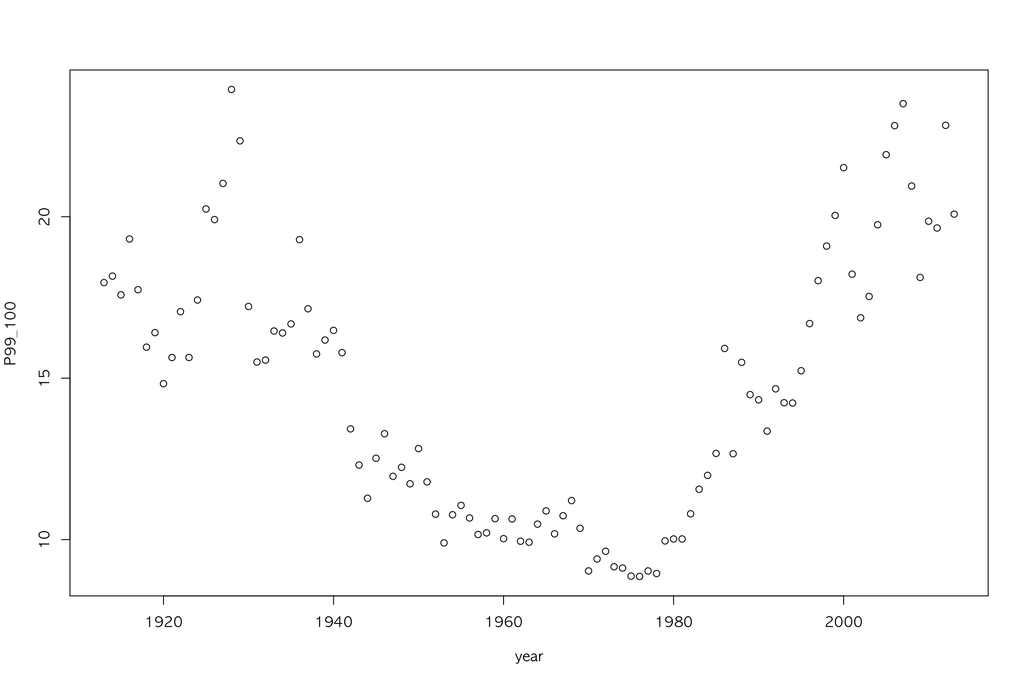

```r
plot(P99_100~year,data=US.top.income.shares.13)
```

최소한의 정보를 주기 위하여 각 자료의 최대값, 최소값을 고려하여 y-축의 범위를 `ylim=c(5,25)`로 설정하고, x-축의 눈금은 비워둔다. 점들을 선으로 이어주고, 점은 다시 삼각형 모양으로 바꾼다.

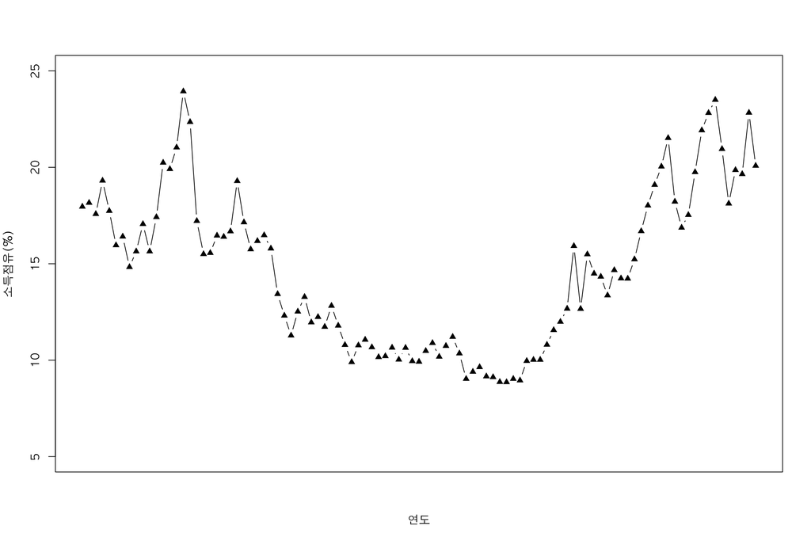

```r
plot(P99_100~year,data=US.top.income.shares.13, xlab="연도", ylab="소득점유(%)", ylim=c(5,25), xaxt="n", type="b",pch=17)
```

이제 x-축에는 연도를 10년 단위로 표시하고, `lines()`를 이용하여 차상위4%와 차차상위5%의 소득 점유율 변화를 함께 그린다.

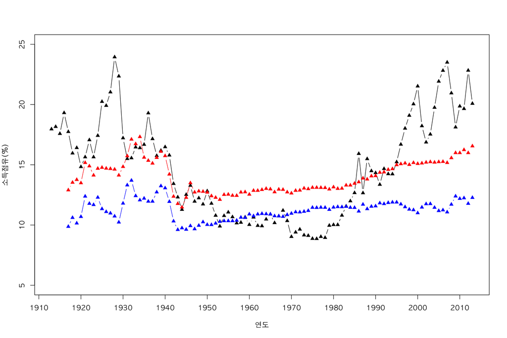

```r
plot(P99_100~year,data=US.top.income.shares.13, xlab="연도", ylab="소득점유(%)", ylim=c(5,25), xaxt="n", type="b",pch=17)
axis(side=1, at=seq(1910, 2010, by=10), labels=seq(1910, 2010, by=10))
lines(P95_99~year,data=US.top.income.shares.13,type="b", pch=17, col="red")
lines(P90_95~year,data=US.top.income.shares.13,type="b", pch=17, col="blue")
```

도표의 가독성을 높이기 위하여 x-축과 y-축을 가로지르는 격자를 설치한다.

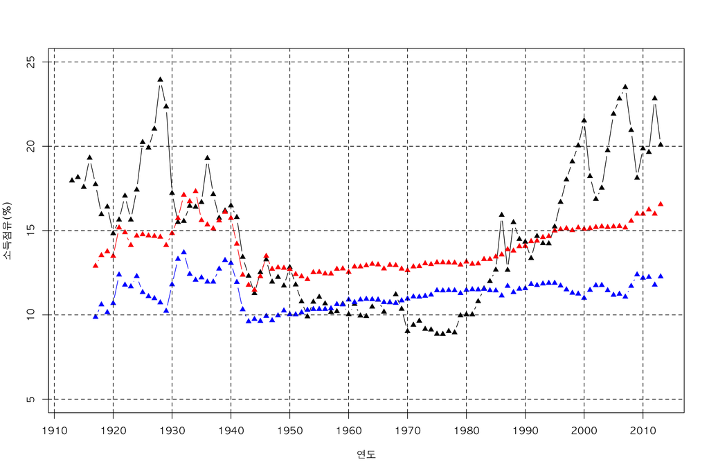

```r
plot(P99_100~year,data=US.top.income.shares.13, xlab="연도", ylab="소득점유(%)", ylim=c(5,25), xaxt="n", type="b",pch=17)
axis(side=1, at=seq(1910, 2010, by=10), labels=seq(1910, 2010, by=10))
lines(P95_99~year,data=US.top.income.shares.13,type="b", pch=17, col="red")
lines(P90_95~year,data=US.top.income.shares.13,type="b", pch=17, col="blue")
abline(h=seq(5,25, by=5), lty=2)
abline(v=seq(1910, 2010, by=10), lty=2)
```

TabFig2013prel.xls의 Table 0 시트에 나와 있는 정보를 활용하여 범례를 만든다.

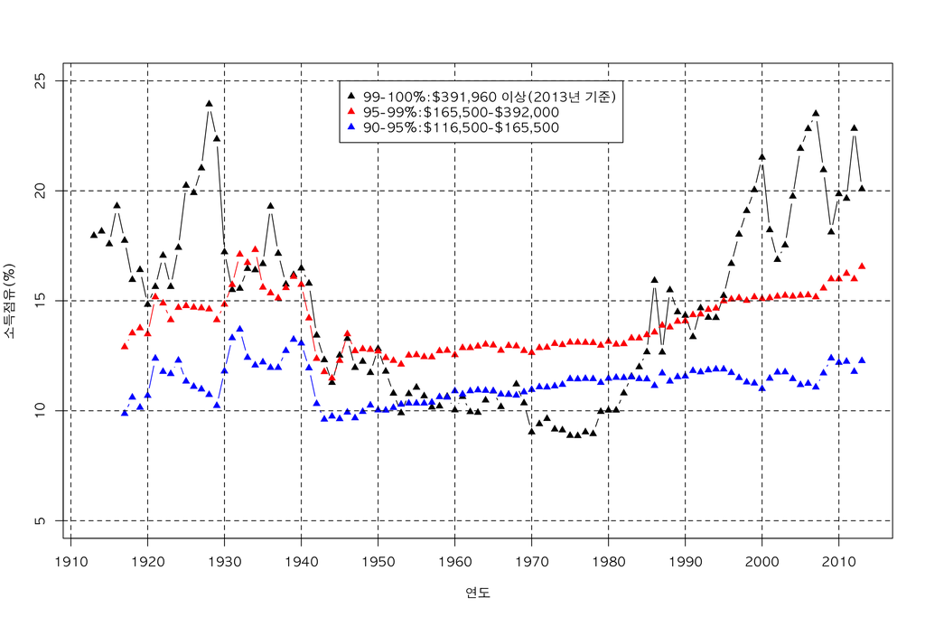

```r
plot(P99_100~year,data=US.top.income.shares.13, xlab="연도", ylab="소득점유(%)", ylim=c(5,25), xaxt="n", type="b",pch=17)
axis(side=1, at=seq(1910, 2010, by=10), labels=seq(1910, 2010, by=10))
lines(P95_99~year,data=US.top.income.shares.13,type="b", pch=17, col="red")
lines(P90_95~year,data=US.top.income.shares.13,type="b", pch=17, col="blue")
abline(h=seq(5,25, by=5), lty=2)
abline(v=seq(1910, 2010, by=10), lty=2)
legend(x=1945, y=25, legend=c("99-100%:$391,960 이상(2013년 기준)","95-99%:$165,500-$392,000","90-95%:$116,500-$165,500"), pch=17, col=c("black", "red", "blue"))
```

메인 타이틀을 입력하고, 상위1%의 소득점유율이 최고에 달했던 연도를 표시한다.

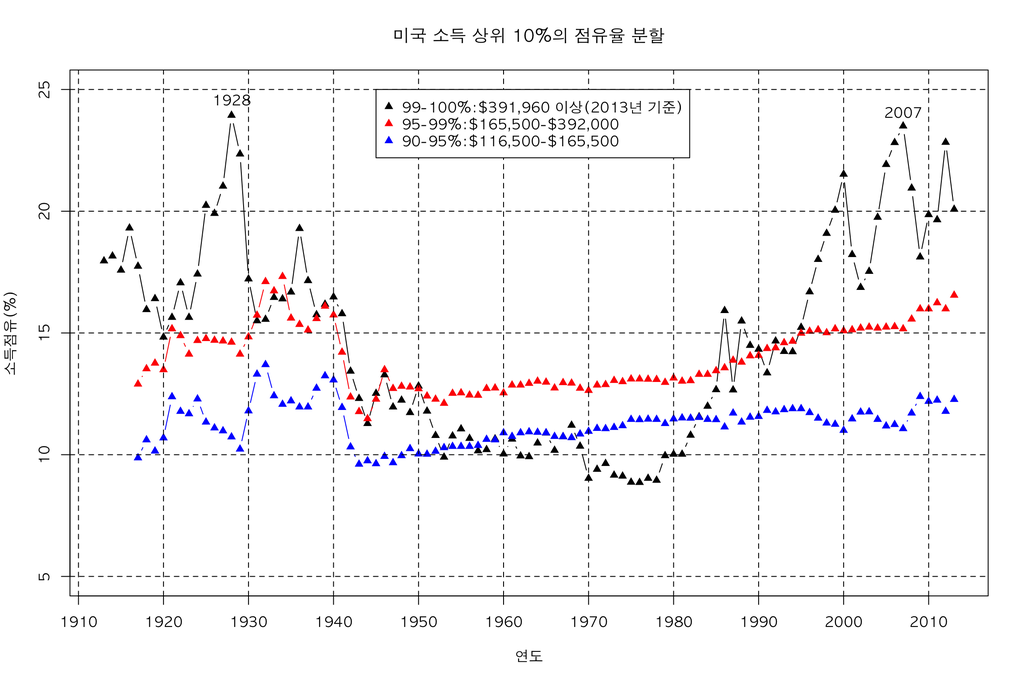

```r
plot(P99_100~year,data=US.top.income.shares.13, xlab="연도", ylab="소득점유(%)", ylim=c(5,25), xaxt="n", type="b",pch=17)
axis(side=1, at=seq(1910, 2010, by=10), labels=seq(1910, 2010, by=10))
lines(P95_99~year,data=US.top.income.shares.13,type="b", pch=17, col="red")
lines(P90_95~year,data=US.top.income.shares.13,type="b", pch=17, col="blue")
abline(h=seq(5,25, by=5), lty=2)
abline(v=seq(1910, 2010, by=10), lty=2)
legend(x=1945, y=25, legend=c("99-100%:$391,960 이상(2013년 기준)","95-99%:$165,500-$392,000","90-95%:$116,500-$165,500"), pch=17, col=c("black", "red", "blue"))
title(main="미국 소득 상위 10%의 점유율 분할")
text(x=c(1928, 2007), y=c(24, 23.5), labels=c("1928", "2007"), pos=3)
```

역사적으로 각 시기를 어떻게 부르고 있는지 텍스트를 추가한다.

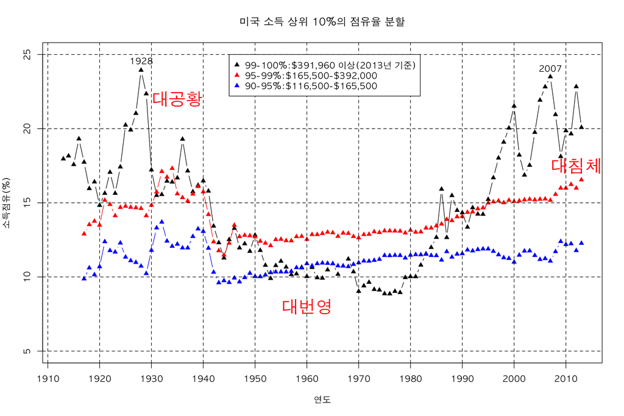

```r
plot(P99_100~year,data=US.top.income.shares.13, xlab="연도", ylab="소득점유(%)", ylim=c(5,25), xaxt="n", type="b",pch=17)
axis(side=1, at=seq(1910, 2010, by=10), labels=seq(1910, 2010, by=10))
lines(P95_99~year,data=US.top.income.shares.13,type="b", pch=17, col="red")
lines(P90_95~year,data=US.top.income.shares.13,type="b", pch=17, col="blue")
abline(h=seq(5,25, by=5), lty=2)
abline(v=seq(1910, 2010, by=10), lty=2)
legend(x=1945, y=25, legend=c("99-100%:$391,960 이상(2013년 기준)","95-99%:$165,500-$392,000","90-95%:$116,500-$165,500"), pch=17, col=c("black", "red", "blue"))
title(main="미국 소득 상위 10%의 점유율 분할")
text(x=c(1928, 2007), y=c(24, 23.5), labels=c("1928", "2007"), pos=3)
text(x=1935, y=22, label="대공황", cex=2.0, col="red")
text(x=1960, y=8, label="대번영", cex=2.0, col="red")
text(x=2012, y=17.5, label="대침체", cex=2.0, col="red")
```